# Risk Factor Analysis

## Outcome Variable

**Outcome Variable:** whz

## Predictor Variables

**Intervention Variable:** perdiar24

**Adjustment Set:**

- arm
- sex
- meducyrs
- feducyrs
- hhwealth_quart
- hfoodsec
- vagbrth
- hdlvry
- W_birthwt
- W_birthlen
- single
- W_nrooms
- month
- brthmon
- impfloor
- impsan
- safeh20
- delta_meducyrs
- delta_feducyrs
- delta_hhwealth_quart
- delta_hfoodsec
- delta_vagbrth
- delta_hdlvry
- delta_W_birthwt
- delta_W_birthlen
- delta_single
- delta_W_nrooms
- delta_month
- delta_brthmon
- delta_impfloor
- delta_impsan
- delta_safeh20

## Stratifying Variables

The analysis was stratified on these variable(s):

- agecat
- studyid
- country

## Data Summary

| agecat | studyid | country | perdiar24 | n_cell | n | outcome_variable |
| --- | --- | --- | --- | --- | --- | --- |
| Birth | ki0047075b-MAL-ED | BANGLADESH | 0% | 14 | 215 | whz |
| Birth | ki0047075b-MAL-ED | BANGLADESH | (0%, 5%] | 127 | 215 | whz |
| Birth | ki0047075b-MAL-ED | BANGLADESH | >5% | 74 | 215 | whz |
| Birth | ki0047075b-MAL-ED | BRAZIL | 0% | 34 | 62 | whz |
| Birth | ki0047075b-MAL-ED | BRAZIL | (0%, 5%] | 26 | 62 | whz |
| Birth | ki0047075b-MAL-ED | BRAZIL | >5% | 2 | 62 | whz |
| Birth | ki0047075b-MAL-ED | INDIA | 0% | 5 | 45 | whz |
| Birth | ki0047075b-MAL-ED | INDIA | (0%, 5%] | 31 | 45 | whz |
| Birth | ki0047075b-MAL-ED | INDIA | >5% | 9 | 45 | whz |
| Birth | ki0047075b-MAL-ED | NEPAL | 0% | 2 | 26 | whz |
| Birth | ki0047075b-MAL-ED | NEPAL | (0%, 5%] | 19 | 26 | whz |
| Birth | ki0047075b-MAL-ED | NEPAL | >5% | 5 | 26 | whz |
| Birth | ki0047075b-MAL-ED | PERU | 0% | 21 | 228 | whz |
| Birth | ki0047075b-MAL-ED | PERU | (0%, 5%] | 87 | 228 | whz |
| Birth | ki0047075b-MAL-ED | PERU | >5% | 120 | 228 | whz |
| Birth | ki0047075b-MAL-ED | SOUTH AFRICA | 0% | 42 | 112 | whz |
| Birth | ki0047075b-MAL-ED | SOUTH AFRICA | (0%, 5%] | 69 | 112 | whz |
| Birth | ki0047075b-MAL-ED | SOUTH AFRICA | >5% | 1 | 112 | whz |
| Birth | ki0047075b-MAL-ED | TANZANIA, UNITED REPUBLIC OF | 0% | 7 | 115 | whz |
| Birth | ki0047075b-MAL-ED | TANZANIA, UNITED REPUBLIC OF | (0%, 5%] | 77 | 115 | whz |
| Birth | ki0047075b-MAL-ED | TANZANIA, UNITED REPUBLIC OF | >5% | 31 | 115 | whz |
| Birth | ki1000109-EE | PAKISTAN | 0% | 115 | 177 | whz |
| Birth | ki1000109-EE | PAKISTAN | (0%, 5%] | 62 | 177 | whz |
| Birth | ki1000109-EE | PAKISTAN | >5% | 0 | 177 | whz |
| Birth | ki1017093-NIH-Birth | BANGLADESH | 0% | 46 | 572 | whz |
| Birth | ki1017093-NIH-Birth | BANGLADESH | (0%, 5%] | 327 | 572 | whz |
| Birth | ki1017093-NIH-Birth | BANGLADESH | >5% | 199 | 572 | whz |
| Birth | ki1017093b-PROVIDE | BANGLADESH | 0% | 55 | 532 | whz |
| Birth | ki1017093b-PROVIDE | BANGLADESH | (0%, 5%] | 322 | 532 | whz |
| Birth | ki1017093b-PROVIDE | BANGLADESH | >5% | 155 | 532 | whz |

[output cut: 102 more lines]

The following strata were considered:

- agecat: 24 months, studyid: ki0047075b-MAL-ED, country: BANGLADESH
- agecat: 24 months, studyid: ki0047075b-MAL-ED, country: BRAZIL
- agecat: 24 months, studyid: ki0047075b-MAL-ED, country: INDIA
- agecat: 24 months, studyid: ki0047075b-MAL-ED, country: NEPAL
- agecat: 24 months, studyid: ki0047075b-MAL-ED, country: PERU
- agecat: 24 months, studyid: ki0047075b-MAL-ED, country: SOUTH AFRICA
- agecat: 24 months, studyid: ki0047075b-MAL-ED, country: TANZANIA, UNITED REPUBLIC OF
- agecat: 24 months, studyid: ki1000109-EE, country: PAKISTAN
- agecat: 24 months, studyid: ki1017093-NIH-Birth, country: BANGLADESH
- agecat: 24 months, studyid: ki1017093b-PROVIDE, country: BANGLADESH
- agecat: 24 months, studyid: ki1017093c-NIH-Crypto, country: BANGLADESH
- agecat: 24 months, studyid: ki1114097-CMIN, country: BANGLADESH
- agecat: 24 months, studyid: ki1114097-CONTENT, country: PERU
- agecat: 24 months, studyid: kiGH5241-JiVitA-4, country: BANGLADESH
- agecat: 6 months, studyid: ki0047075b-MAL-ED, country: BANGLADESH
- agecat: 6 months, studyid: ki0047075b-MAL-ED, country: BRAZIL
- agecat: 6 months, studyid: ki0047075b-MAL-ED, country: INDIA
- agecat: 6 months, studyid: ki0047075b-MAL-ED, country: NEPAL
- agecat: 6 months, studyid: ki0047075b-MAL-ED, country: PERU
- agecat: 6 months, studyid: ki0047075b-MAL-ED, country: SOUTH AFRICA
- agecat: 6 months, studyid: ki0047075b-MAL-ED, country: TANZANIA, UNITED REPUBLIC OF
- agecat: 6 months, studyid: ki1000109-EE, country: PAKISTAN
- agecat: 6 months, studyid: ki1000304b-SAS-FoodSuppl, country: INDIA
- agecat: 6 months, studyid: ki1017093-NIH-Birth, country: BANGLADESH
- agecat: 6 months, studyid: ki1017093b-PROVIDE, country: BANGLADESH
- agecat: 6 months, studyid: ki1017093c-NIH-Crypto, country: BANGLADESH
- agecat: 6 months, studyid: ki1112895-Guatemala BSC, country: GUATEMALA
- agecat: 6 months, studyid: ki1114097-CMIN, country: BANGLADESH
- agecat: 6 months, studyid: ki1114097-CONTENT, country: PERU
- agecat: 6 months, studyid: kiGH5241-JiVitA-4, country: BANGLADESH
- agecat: Birth, studyid: ki0047075b-MAL-ED, country: BANGLADESH
- agecat: Birth, studyid: ki0047075b-MAL-ED, country: BRAZIL
- agecat: Birth, studyid: ki0047075b-MAL-ED, country: INDIA
- agecat: Birth, studyid: ki0047075b-MAL-ED, country: NEPAL
- agecat: Birth, studyid: ki0047075b-MAL-ED, country: PERU
- agecat: Birth, studyid: ki0047075b-MAL-ED, country: SOUTH AFRICA
- agecat: Birth, studyid: ki0047075b-MAL-ED, country: TANZANIA, UNITED REPUBLIC OF
- agecat: Birth, studyid: ki1000109-EE, country: PAKISTAN
- agecat: Birth, studyid: ki1017093-NIH-Birth, country: BANGLADESH
- agecat: Birth, studyid: ki1017093b-PROVIDE, country: BANGLADESH
- agecat: Birth, studyid: ki1017093c-NIH-Crypto, country: BANGLADESH
- agecat: Birth, studyid: ki1114097-CMIN, country: BANGLADESH
- agecat: Birth, studyid: ki1114097-CONTENT, country: PERU
- agecat: Birth, studyid: kiGH5241-JiVitA-4, country: BANGLADESH

### Dropped Strata

Some strata were dropped due to rare outcomes:

- agecat: Birth, studyid: ki0047075b-MAL-ED, country: BRAZIL
- agecat: Birth, studyid: ki0047075b-MAL-ED, country: NEPAL
- agecat: Birth, studyid: ki0047075b-MAL-ED, country: SOUTH AFRICA
- agecat: Birth, studyid: ki1000109-EE, country: PAKISTAN
- agecat: Birth, studyid: ki1114097-CMIN, country: BANGLADESH
- agecat: Birth, studyid: ki1114097-CONTENT, country: PERU
- agecat: 6 months, studyid: ki0047075b-MAL-ED, country: BRAZIL
- agecat: 6 months, studyid: ki0047075b-MAL-ED, country: INDIA
- agecat: 6 months, studyid: ki0047075b-MAL-ED, country: SOUTH AFRICA
- agecat: 6 months, studyid: ki1000109-EE, country: PAKISTAN
- agecat: 6 months, studyid: ki1114097-CMIN, country: BANGLADESH
- agecat: 24 months, studyid: ki0047075b-MAL-ED, country: BRAZIL
- agecat: 24 months, studyid: ki0047075b-MAL-ED, country: INDIA
- agecat: 24 months, studyid: ki0047075b-MAL-ED, country: PERU
- agecat: 24 months, studyid: ki0047075b-MAL-ED, country: SOUTH AFRICA
- agecat: 24 months, studyid: ki1000109-EE, country: PAKISTAN
- agecat: 24 months, studyid: ki1114097-CMIN, country: BANGLADESH
- agecat: 24 months, studyid: ki1114097-CONTENT, country: PERU

## Methods Detail

We’re interested in the causal parameters $E[Y_a]$ for all values of $a \in \mathcal{A}$. These parameters represent the mean outcome if, possibly contrary to fact, we intervened to set all units to have $A=a$. Under the randomization and positivity assumptions, these are identified by the statistical parameters $\psi_a=E_W[E_{Y|A,W}(Y|A=a,W)]$. In addition, we’re interested in the mean of $Y$, $E[Y]$ under no intervention (the observed mean). We will estimate these parameters by using SuperLearner to fit the relevant likelihood factors – $E_{Y|A,W}(Y|A=a,W)$ and $p(A=a|W)$, and then updating our likelihood fit using a joint TMLE.

For unadjusted analyses ($W=\{\}$), initial likelihoods were estimated using Lrnr_glm to estimate the simple $E(Y|A)$ and Lrnr_mean to estimate $p(A)$. For adjusted analyses, a small library containing Lrnr_glmnet, Lrnr_xgboost, and Lrnr_mean was used.

Having estimated these parameters, we will then use the delta method to estimate relative risks and attributable risks relative to a prespecified baseline level of $A$.

# Results Detail

## Results Plots

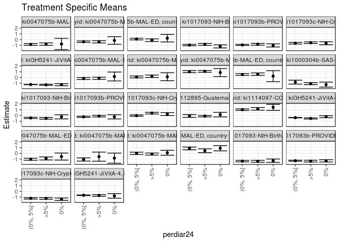

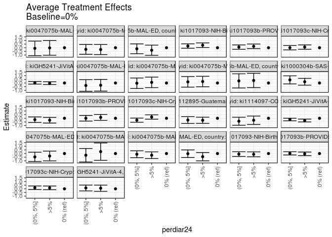

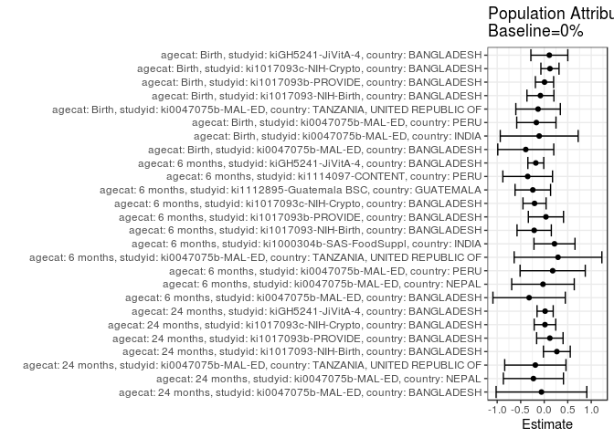

## Results Table

### Parameter: TSM

| agecat | studyid | country | intervention_level | baseline_level | estimate | ci_lower | ci_upper |
| --- | --- | --- | --- | --- | --- | --- | --- |
| Birth | ki0047075b-MAL-ED | BANGLADESH | 0% | NA | -0.5498187 | -1.1645658 | 0.0649283 |
| Birth | ki0047075b-MAL-ED | BANGLADESH | (0%, 5%] | NA | -1.0107128 | -1.1932847 | -0.8281408 |
| Birth | ki0047075b-MAL-ED | BANGLADESH | >5% | NA | -0.8854839 | -1.1499985 | -0.6209694 |
| Birth | ki0047075b-MAL-ED | INDIA | 0% | NA | -0.8260000 | -1.7120476 | 0.0600476 |
| Birth | ki0047075b-MAL-ED | INDIA | (0%, 5%] | NA | -1.0574194 | -1.3366625 | -0.7781762 |
| Birth | ki0047075b-MAL-ED | INDIA | >5% | NA | -0.5611111 | -1.3534381 | 0.2312159 |
| Birth | ki0047075b-MAL-ED | PERU | 0% | NA | 0.1150126 | -0.3103954 | 0.5404206 |
| Birth | ki0047075b-MAL-ED | PERU | (0%, 5%] | NA | 0.0169138 | -0.1881715 | 0.2219991 |
| Birth | ki0047075b-MAL-ED | PERU | >5% | NA | -0.1120021 | -0.2909117 | 0.0669075 |
| Birth | ki0047075b-MAL-ED | TANZANIA, UNITED REPUBLIC OF | 0% | NA | 0.8928571 | 0.4313181 | 1.3543962 |
| Birth | ki0047075b-MAL-ED | TANZANIA, UNITED REPUBLIC OF | (0%, 5%] | NA | 0.8712987 | 0.6273536 | 1.1152438 |
| Birth | ki0047075b-MAL-ED | TANZANIA, UNITED REPUBLIC OF | >5% | NA | 0.4625806 | 0.1300967 | 0.7950646 |
| Birth | ki1017093-NIH-Birth | BANGLADESH | 0% | NA | -1.2720004 | -1.5668851 | -0.9771157 |
| Birth | ki1017093-NIH-Birth | BANGLADESH | (0%, 5%] | NA | -1.3474351 | -1.4739576 | -1.2209126 |
| Birth | ki1017093-NIH-Birth | BANGLADESH | >5% | NA | -1.3773906 | -1.5407417 | -1.2140396 |
| Birth | ki1017093b-PROVIDE | BANGLADESH | 0% | NA | -1.3048993 | -1.5061160 | -1.1036826 |
| Birth | ki1017093b-PROVIDE | BANGLADESH | (0%, 5%] | NA | -1.2774918 | -1.3722490 | -1.1827346 |
| Birth | ki1017093b-PROVIDE | BANGLADESH | >5% | NA | -1.3490646 | -1.5047413 | -1.1933879 |
| Birth | ki1017093c-NIH-Crypto | BANGLADESH | 0% | NA | -1.3663083 | -1.5788431 | -1.1537734 |
| Birth | ki1017093c-NIH-Crypto | BANGLADESH | (0%, 5%] | NA | -1.2158811 | -1.3393320 | -1.0924302 |
| Birth | ki1017093c-NIH-Crypto | BANGLADESH | >5% | NA | -1.2359733 | -1.3868926 | -1.0850541 |
| Birth | kiGH5241-JiVitA-4 | BANGLADESH | 0% | NA | -0.7976752 | -1.1997299 | -0.3956206 |
| Birth | kiGH5241-JiVitA-4 | BANGLADESH | (0%, 5%] | NA | -0.6821949 | -0.7376672 | -0.6267226 |
| Birth | kiGH5241-JiVitA-4 | BANGLADESH | >5% | NA | -0.7145335 | -0.8619247 | -0.5671422 |
| 6 months | ki0047075b-MAL-ED | BANGLADESH | 0% | NA | 0.1833333 | -0.5948965 | 0.9615632 |
| 6 months | ki0047075b-MAL-ED | BANGLADESH | (0%, 5%] | NA | -0.1581455 | -0.3337303 | 0.0174392 |
| 6 months | ki0047075b-MAL-ED | BANGLADESH | >5% | NA | -0.1271326 | -0.3185947 | 0.0643295 |
| 6 months | ki0047075b-MAL-ED | NEPAL | 0% | NA | 0.1367406 | -0.5561929 | 0.8296740 |
| 6 months | ki0047075b-MAL-ED | NEPAL | (0%, 5%] | NA | 0.1055408 | -0.0665195 | 0.2776012 |
| 6 months | ki0047075b-MAL-ED | NEPAL | >5% | NA | 0.2232850 | 0.0096832 | 0.4368868 |
| 6 months | ki0047075b-MAL-ED | PERU | 0% | NA | 0.8728571 | 0.1723061 | 1.5734082 |
| 6 months | ki0047075b-MAL-ED | PERU | (0%, 5%] | NA | 1.0295260 | 0.8447495 | 1.2143025 |
| 6 months | ki0047075b-MAL-ED | PERU | >5% | NA | 1.0771231 | 0.9121893 | 1.2420570 |
| 6 months | ki0047075b-MAL-ED | TANZANIA, UNITED REPUBLIC OF | 0% | NA | 0.2427778 | -0.7161220 | 1.2016775 |
| 6 months | ki0047075b-MAL-ED | TANZANIA, UNITED REPUBLIC OF | (0%, 5%] | NA | 0.5318644 | 0.3720281 | 0.6917007 |
| 6 months | ki0047075b-MAL-ED | TANZANIA, UNITED REPUBLIC OF | >5% | NA | 0.5921585 | 0.3766024 | 0.8077146 |
| 6 months | ki1000304b-SAS-FoodSuppl | INDIA | 0% | NA | -1.2303986 | -1.6672681 | -0.7935290 |
| 6 months | ki1000304b-SAS-FoodSuppl | INDIA | (0%, 5%] | NA | -0.7996460 | -1.1428374 | -0.4564545 |
| 6 months | ki1000304b-SAS-FoodSuppl | INDIA | >5% | NA | -1.0568754 | -1.2289853 | -0.8847655 |
| 6 months | ki1017093-NIH-Birth | BANGLADESH | 0% | NA | -0.2340976 | -0.5968148 | 0.1286195 |
| 6 months | ki1017093-NIH-Birth | BANGLADESH | (0%, 5%] | NA | -0.4283435 | -0.5454914 | -0.3111956 |
| 6 months | ki1017093-NIH-Birth | BANGLADESH | >5% | NA | -0.5000045 | -0.6515347 | -0.3484742 |
| 6 months | ki1017093b-PROVIDE | BANGLADESH | 0% | NA | -0.2355935 | -0.6092178 | 0.1380307 |
| 6 months | ki1017093b-PROVIDE | BANGLADESH | (0%, 5%] | NA | -0.2324453 | -0.3348655 | -0.1300252 |
| 6 months | ki1017093b-PROVIDE | BANGLADESH | >5% | NA | -0.1150729 | -0.2637117 | 0.0335659 |
| 6 months | ki1017093c-NIH-Crypto | BANGLADESH | 0% | NA | 0.2354672 | -0.0239075 | 0.4948420 |
| 6 months | ki1017093c-NIH-Crypto | BANGLADESH | (0%, 5%] | NA | -0.0221732 | -0.1421991 | 0.0978527 |
| 6 months | ki1017093c-NIH-Crypto | BANGLADESH | >5% | NA | 0.4092938 | 0.2578054 | 0.5607823 |
| 6 months | ki1112895-Guatemala BSC | GUATEMALA | 0% | NA | 0.1582706 | -0.2417787 | 0.5583198 |
| 6 months | ki1112895-Guatemala BSC | GUATEMALA | (0%, 5%] | NA | -0.0849904 | -0.3259587 | 0.1559779 |
| 6 months | ki1112895-Guatemala BSC | GUATEMALA | >5% | NA | -0.1145308 | -0.2460379 | 0.0169763 |
| 6 months | ki1114097-CONTENT | PERU | 0% | NA | 1.4197500 | 0.8897030 | 1.9497970 |
| 6 months | ki1114097-CONTENT | PERU | (0%, 5%] | NA | 1.0154953 | 0.8771516 | 1.1538390 |
| 6 months | ki1114097-CONTENT | PERU | >5% | NA | 1.1491642 | 0.9229924 | 1.3753360 |
| 6 months | kiGH5241-JiVitA-4 | BANGLADESH | 0% | NA | -0.2111333 | -0.3852650 | -0.0370016 |
| 6 months | kiGH5241-JiVitA-4 | BANGLADESH | (0%, 5%] | NA | -0.3807649 | -0.4196933 | -0.3418366 |
| 6 months | kiGH5241-JiVitA-4 | BANGLADESH | >5% | NA | -0.5199873 | -0.6176531 | -0.4223215 |
| 24 months | ki0047075b-MAL-ED | BANGLADESH | 0% | NA | -0.7608333 | -1.7455859 | 0.2239193 |
| 24 months | ki0047075b-MAL-ED | BANGLADESH | (0%, 5%] | NA | -0.8440769 | -0.9945327 | -0.6936211 |
| 24 months | ki0047075b-MAL-ED | BANGLADESH | >5% | NA | -0.7815132 | -0.9897171 | -0.5733093 |
| 24 months | ki0047075b-MAL-ED | NEPAL | 0% | NA | -0.1454977 | -0.8061970 | 0.5152016 |
| 24 months | ki0047075b-MAL-ED | NEPAL | (0%, 5%] | NA | -0.3675394 | -0.5061343 | -0.2289445 |
| 24 months | ki0047075b-MAL-ED | NEPAL | >5% | NA | -0.3905061 | -0.5979775 | -0.1830347 |
| 24 months | ki0047075b-MAL-ED | TANZANIA, UNITED REPUBLIC OF | 0% | NA | 0.2433333 | -0.4146176 | 0.9012843 |
| 24 months | ki0047075b-MAL-ED | TANZANIA, UNITED REPUBLIC OF | (0%, 5%] | NA | 0.0989530 | -0.0508664 | 0.2487724 |
| 24 months | ki0047075b-MAL-ED | TANZANIA, UNITED REPUBLIC OF | >5% | NA | -0.0994231 | -0.3337823 | 0.1349362 |
| 24 months | ki1017093-NIH-Birth | BANGLADESH | 0% | NA | -1.1800000 | -1.4547770 | -0.9052230 |
| 24 months | ki1017093-NIH-Birth | BANGLADESH | (0%, 5%] | NA | -0.9456415 | -1.0692081 | -0.8220748 |
| 24 months | ki1017093-NIH-Birth | BANGLADESH | >5% | NA | -0.8370172 | -1.0005302 | -0.6735043 |
| 24 months | ki1017093b-PROVIDE | BANGLADESH | 0% | NA | -1.0127778 | -1.2883897 | -0.7371658 |
| 24 months | ki1017093b-PROVIDE | BANGLADESH | (0%, 5%] | NA | -0.9233081 | -1.0226788 | -0.8239373 |
| 24 months | ki1017093b-PROVIDE | BANGLADESH | >5% | NA | -0.8173851 | -0.9715768 | -0.6631933 |
| 24 months | ki1017093c-NIH-Crypto | BANGLADESH | 0% | NA | -0.6263977 | -0.8860899 | -0.3667056 |
| 24 months | ki1017093c-NIH-Crypto | BANGLADESH | (0%, 5%] | NA | -0.6256545 | -0.7724081 | -0.4789009 |
| 24 months | ki1017093c-NIH-Crypto | BANGLADESH | >5% | NA | -0.5346598 | -0.6825231 | -0.3867965 |
| 24 months | kiGH5241-JiVitA-4 | BANGLADESH | 0% | NA | -1.2424763 | -1.4201536 | -1.0647990 |
| 24 months | kiGH5241-JiVitA-4 | BANGLADESH | (0%, 5%] | NA | -1.2172599 | -1.2500777 | -1.1844421 |
| 24 months | kiGH5241-JiVitA-4 | BANGLADESH | >5% | NA | -1.2662938 | -1.3588507 | -1.1737369 |

### Parameter: E(Y)

| agecat | studyid | country | intervention_level | baseline_level | estimate | ci_lower | ci_upper |
| --- | --- | --- | --- | --- | --- | --- | --- |
| Birth | ki0047075b-MAL-ED | BANGLADESH | NA | NA | -0.9418605 | -1.0869834 | -0.7967375 |
| Birth | ki0047075b-MAL-ED | INDIA | NA | NA | -0.9324444 | -1.2067907 | -0.6580982 |
| Birth | ki0047075b-MAL-ED | PERU | NA | NA | -0.0520175 | -0.1725298 | 0.0684947 |
| Birth | ki0047075b-MAL-ED | TANZANIA, UNITED REPUBLIC OF | NA | NA | 0.7624348 | 0.5710709 | 0.9537986 |
| Birth | ki1017093-NIH-Birth | BANGLADESH | NA | NA | -1.3525437 | -1.4473932 | -1.2576942 |
| Birth | ki1017093b-PROVIDE | BANGLADESH | NA | NA | -1.2984586 | -1.3752758 | -1.2216415 |
| Birth | ki1017093c-NIH-Crypto | BANGLADESH | NA | NA | -1.2441513 | -1.3281130 | -1.1601897 |
| Birth | kiGH5241-JiVitA-4 | BANGLADESH | NA | NA | -0.6886269 | -0.7410452 | -0.6362086 |
| 6 months | ki0047075b-MAL-ED | BANGLADESH | NA | NA | -0.1376763 | -0.2664642 | -0.0088885 |
| 6 months | ki0047075b-MAL-ED | NEPAL | NA | NA | 0.1104308 | -0.0208643 | 0.2417259 |
| 6 months | ki0047075b-MAL-ED | PERU | NA | NA | 1.0528816 | 0.9313005 | 1.1744626 |
| 6 months | ki0047075b-MAL-ED | TANZANIA, UNITED REPUBLIC OF | NA | NA | 0.5362213 | 0.4049390 | 0.6675036 |
| 6 months | ki1000304b-SAS-FoodSuppl | INDIA | NA | NA | -1.0121579 | -1.1280429 | -0.8962729 |
| 6 months | ki1017093-NIH-Birth | BANGLADESH | NA | NA | -0.4474038 | -0.5378167 | -0.3569909 |
| 6 months | ki1017093b-PROVIDE | BANGLADESH | NA | NA | -0.1990907 | -0.2817968 | -0.1163845 |
| 6 months | ki1017093c-NIH-Crypto | BANGLADESH | NA | NA | 0.0297622 | -0.0491685 | 0.1086930 |
| 6 months | ki1112895-Guatemala BSC | GUATEMALA | NA | NA | -0.0840134 | -0.1945572 | 0.0265305 |
| 6 months | ki1114097-CONTENT | PERU | NA | NA | 1.0684318 | 0.9515274 | 1.1853362 |
| 6 months | kiGH5241-JiVitA-4 | BANGLADESH | NA | NA | -0.3898055 | -0.4270507 | -0.3525603 |
| 24 months | ki0047075b-MAL-ED | BANGLADESH | NA | NA | -0.8192925 | -0.9412667 | -0.6973182 |
| 24 months | ki0047075b-MAL-ED | NEPAL | NA | NA | -0.3749123 | -0.4886073 | -0.2612173 |
| 24 months | ki0047075b-MAL-ED | TANZANIA, UNITED REPUBLIC OF | NA | NA | 0.0547975 | -0.0703378 | 0.1799328 |
| 24 months | ki1017093-NIH-Birth | BANGLADESH | NA | NA | -0.9115790 | -1.0095022 | -0.8136559 |
| 24 months | ki1017093b-PROVIDE | BANGLADESH | NA | NA | -0.8928670 | -0.9755153 | -0.8102187 |
| 24 months | ki1017093c-NIH-Crypto | BANGLADESH | NA | NA | -0.6103502 | -0.7050157 | -0.5156847 |
| 24 months | kiGH5241-JiVitA-4 | BANGLADESH | NA | NA | -1.2231088 | -1.2549632 | -1.1912543 |

### Parameter: ATE

| agecat | studyid | country | intervention_level | baseline_level | estimate | ci_lower | ci_upper |
| --- | --- | --- | --- | --- | --- | --- | --- |
| Birth | ki0047075b-MAL-ED | BANGLADESH | 0% | 0% | 0.0000000 | 0.0000000 | 0.0000000 |
| Birth | ki0047075b-MAL-ED | BANGLADESH | (0%, 5%] | 0% | -0.4608940 | -1.1027633 | 0.1809753 |
| Birth | ki0047075b-MAL-ED | BANGLADESH | >5% | 0% | -0.3356652 | -1.0053176 | 0.3339872 |
| Birth | ki0047075b-MAL-ED | INDIA | 0% | 0% | 0.0000000 | 0.0000000 | 0.0000000 |
| Birth | ki0047075b-MAL-ED | INDIA | (0%, 5%] | 0% | -0.2314194 | -1.1604280 | 0.6975893 |
| Birth | ki0047075b-MAL-ED | INDIA | >5% | 0% | 0.2648889 | -0.9237500 | 1.4535278 |
| Birth | ki0047075b-MAL-ED | PERU | 0% | 0% | 0.0000000 | 0.0000000 | 0.0000000 |
| Birth | ki0047075b-MAL-ED | PERU | (0%, 5%] | 0% | -0.0980988 | -0.5724840 | 0.3762865 |
| Birth | ki0047075b-MAL-ED | PERU | >5% | 0% | -0.2270147 | -0.6858742 | 0.2318449 |
| Birth | ki0047075b-MAL-ED | TANZANIA, UNITED REPUBLIC OF | 0% | 0% | 0.0000000 | 0.0000000 | 0.0000000 |
| Birth | ki0047075b-MAL-ED | TANZANIA, UNITED REPUBLIC OF | (0%, 5%] | 0% | -0.0215584 | -0.5436001 | 0.5004833 |
| Birth | ki0047075b-MAL-ED | TANZANIA, UNITED REPUBLIC OF | >5% | 0% | -0.4302765 | -0.9991033 | 0.1385503 |
| Birth | ki1017093-NIH-Birth | BANGLADESH | 0% | 0% | 0.0000000 | 0.0000000 | 0.0000000 |
| Birth | ki1017093-NIH-Birth | BANGLADESH | (0%, 5%] | 0% | -0.0754346 | -0.3958570 | 0.2449877 |
| Birth | ki1017093-NIH-Birth | BANGLADESH | >5% | 0% | -0.1053902 | -0.4420342 | 0.2312537 |
| Birth | ki1017093b-PROVIDE | BANGLADESH | 0% | 0% | 0.0000000 | 0.0000000 | 0.0000000 |
| Birth | ki1017093b-PROVIDE | BANGLADESH | (0%, 5%] | 0% | 0.0274075 | -0.1908175 | 0.2456325 |
| Birth | ki1017093b-PROVIDE | BANGLADESH | >5% | 0% | -0.0441653 | -0.2947572 | 0.2064266 |
| Birth | ki1017093c-NIH-Crypto | BANGLADESH | 0% | 0% | 0.0000000 | 0.0000000 | 0.0000000 |
| Birth | ki1017093c-NIH-Crypto | BANGLADESH | (0%, 5%] | 0% | 0.1504272 | -0.0919685 | 0.3928229 |
| Birth | ki1017093c-NIH-Crypto | BANGLADESH | >5% | 0% | 0.1303349 | -0.1272219 | 0.3878917 |
| Birth | kiGH5241-JiVitA-4 | BANGLADESH | 0% | 0% | 0.0000000 | 0.0000000 | 0.0000000 |
| Birth | kiGH5241-JiVitA-4 | BANGLADESH | (0%, 5%] | 0% | 0.1154804 | -0.2874760 | 0.5184367 |
| Birth | kiGH5241-JiVitA-4 | BANGLADESH | >5% | 0% | 0.0831418 | -0.3434583 | 0.5097419 |
| 6 months | ki0047075b-MAL-ED | BANGLADESH | 0% | 0% | 0.0000000 | 0.0000000 | 0.0000000 |
| 6 months | ki0047075b-MAL-ED | BANGLADESH | (0%, 5%] | 0% | -0.3414789 | -1.1392706 | 0.4563129 |
| 6 months | ki0047075b-MAL-ED | BANGLADESH | >5% | 0% | -0.3104659 | -1.1119018 | 0.4909699 |
| 6 months | ki0047075b-MAL-ED | NEPAL | 0% | 0% | 0.0000000 | 0.0000000 | 0.0000000 |
| 6 months | ki0047075b-MAL-ED | NEPAL | (0%, 5%] | 0% | -0.0311997 | -0.7454303 | 0.6830308 |
| 6 months | ki0047075b-MAL-ED | NEPAL | >5% | 0% | 0.0865444 | -0.6361421 | 0.8092310 |
| 6 months | ki0047075b-MAL-ED | PERU | 0% | 0% | 0.0000000 | 0.0000000 | 0.0000000 |
| 6 months | ki0047075b-MAL-ED | PERU | (0%, 5%] | 0% | 0.1566689 | -0.5678407 | 0.8811784 |
| 6 months | ki0047075b-MAL-ED | PERU | >5% | 0% | 0.2042660 | -0.5154387 | 0.9239707 |
| 6 months | ki0047075b-MAL-ED | TANZANIA, UNITED REPUBLIC OF | 0% | 0% | 0.0000000 | 0.0000000 | 0.0000000 |
| 6 months | ki0047075b-MAL-ED | TANZANIA, UNITED REPUBLIC OF | (0%, 5%] | 0% | 0.2890866 | -0.6830432 | 1.2612164 |
| 6 months | ki0047075b-MAL-ED | TANZANIA, UNITED REPUBLIC OF | >5% | 0% | 0.3493807 | -0.6334485 | 1.3322099 |
| 6 months | ki1000304b-SAS-FoodSuppl | INDIA | 0% | 0% | 0.0000000 | 0.0000000 | 0.0000000 |
| 6 months | ki1000304b-SAS-FoodSuppl | INDIA | (0%, 5%] | 0% | 0.4307526 | -0.1246219 | 0.9861271 |
| 6 months | ki1000304b-SAS-FoodSuppl | INDIA | >5% | 0% | 0.1735232 | -0.2953986 | 0.6424449 |
| 6 months | ki1017093-NIH-Birth | BANGLADESH | 0% | 0% | 0.0000000 | 0.0000000 | 0.0000000 |
| 6 months | ki1017093-NIH-Birth | BANGLADESH | (0%, 5%] | 0% | -0.1942459 | -0.5753528 | 0.1868611 |
| 6 months | ki1017093-NIH-Birth | BANGLADESH | >5% | 0% | -0.2659068 | -0.6590948 | 0.1272812 |
| 6 months | ki1017093b-PROVIDE | BANGLADESH | 0% | 0% | 0.0000000 | 0.0000000 | 0.0000000 |
| 6 months | ki1017093b-PROVIDE | BANGLADESH | (0%, 5%] | 0% | 0.0031482 | -0.3841893 | 0.3904857 |
| 6 months | ki1017093b-PROVIDE | BANGLADESH | >5% | 0% | 0.1205206 | -0.2808520 | 0.5218932 |
| 6 months | ki1017093c-NIH-Crypto | BANGLADESH | 0% | 0% | 0.0000000 | 0.0000000 | 0.0000000 |
| 6 months | ki1017093c-NIH-Crypto | BANGLADESH | (0%, 5%] | 0% | -0.2576405 | -0.5423141 | 0.0270331 |
| 6 months | ki1017093c-NIH-Crypto | BANGLADESH | >5% | 0% | 0.1738266 | -0.1256932 | 0.4733463 |
| 6 months | ki1112895-Guatemala BSC | GUATEMALA | 0% | 0% | 0.0000000 | 0.0000000 | 0.0000000 |
| 6 months | ki1112895-Guatemala BSC | GUATEMALA | (0%, 5%] | 0% | -0.2432609 | -0.7105972 | 0.2240753 |
| 6 months | ki1112895-Guatemala BSC | GUATEMALA | >5% | 0% | -0.2728014 | -0.6932855 | 0.1476828 |
| 6 months | ki1114097-CONTENT | PERU | 0% | 0% | 0.0000000 | 0.0000000 | 0.0000000 |
| 6 months | ki1114097-CONTENT | PERU | (0%, 5%] | 0% | -0.4042547 | -0.9520583 | 0.1435489 |
| 6 months | ki1114097-CONTENT | PERU | >5% | 0% | -0.2705858 | -0.8468700 | 0.3056984 |
| 6 months | kiGH5241-JiVitA-4 | BANGLADESH | 0% | 0% | 0.0000000 | 0.0000000 | 0.0000000 |
| 6 months | kiGH5241-JiVitA-4 | BANGLADESH | (0%, 5%] | 0% | -0.1696316 | -0.3446909 | 0.0054276 |
| 6 months | kiGH5241-JiVitA-4 | BANGLADESH | >5% | 0% | -0.3088540 | -0.5035687 | -0.1141394 |
| 24 months | ki0047075b-MAL-ED | BANGLADESH | 0% | 0% | 0.0000000 | 0.0000000 | 0.0000000 |
| 24 months | ki0047075b-MAL-ED | BANGLADESH | (0%, 5%] | 0% | -0.0832436 | -1.0794236 | 0.9129364 |
| 24 months | ki0047075b-MAL-ED | BANGLADESH | >5% | 0% | -0.0206798 | -1.0272018 | 0.9858422 |
| 24 months | ki0047075b-MAL-ED | NEPAL | 0% | 0% | 0.0000000 | 0.0000000 | 0.0000000 |
| 24 months | ki0047075b-MAL-ED | NEPAL | (0%, 5%] | 0% | -0.2220417 | -0.8973239 | 0.4532405 |
| 24 months | ki0047075b-MAL-ED | NEPAL | >5% | 0% | -0.2450084 | -0.9375344 | 0.4475176 |
| 24 months | ki0047075b-MAL-ED | TANZANIA, UNITED REPUBLIC OF | 0% | 0% | 0.0000000 | 0.0000000 | 0.0000000 |
| 24 months | ki0047075b-MAL-ED | TANZANIA, UNITED REPUBLIC OF | (0%, 5%] | 0% | -0.1443803 | -0.8191731 | 0.5304124 |
| 24 months | ki0047075b-MAL-ED | TANZANIA, UNITED REPUBLIC OF | >5% | 0% | -0.3427564 | -1.0412002 | 0.3556873 |
| 24 months | ki1017093-NIH-Birth | BANGLADESH | 0% | 0% | 0.0000000 | 0.0000000 | 0.0000000 |
| 24 months | ki1017093-NIH-Birth | BANGLADESH | (0%, 5%] | 0% | 0.2343585 | -0.0669240 | 0.5356410 |
| 24 months | ki1017093-NIH-Birth | BANGLADESH | >5% | 0% | 0.3429828 | 0.0232346 | 0.6627310 |
| 24 months | ki1017093b-PROVIDE | BANGLADESH | 0% | 0% | 0.0000000 | 0.0000000 | 0.0000000 |
| 24 months | ki1017093b-PROVIDE | BANGLADESH | (0%, 5%] | 0% | 0.0894697 | -0.2035090 | 0.3824484 |
| 24 months | ki1017093b-PROVIDE | BANGLADESH | >5% | 0% | 0.1953927 | -0.1204190 | 0.5112044 |
| 24 months | ki1017093c-NIH-Crypto | BANGLADESH | 0% | 0% | 0.0000000 | 0.0000000 | 0.0000000 |
| 24 months | ki1017093c-NIH-Crypto | BANGLADESH | (0%, 5%] | 0% | 0.0007432 | -0.2946951 | 0.2961815 |
| 24 months | ki1017093c-NIH-Crypto | BANGLADESH | >5% | 0% | 0.0917379 | -0.2049564 | 0.3884323 |
| 24 months | kiGH5241-JiVitA-4 | BANGLADESH | 0% | 0% | 0.0000000 | 0.0000000 | 0.0000000 |
| 24 months | kiGH5241-JiVitA-4 | BANGLADESH | (0%, 5%] | 0% | 0.0252164 | -0.1528289 | 0.2032616 |
| 24 months | kiGH5241-JiVitA-4 | BANGLADESH | >5% | 0% | -0.0238175 | -0.2213085 | 0.1736734 |

### Parameter: PAR

| agecat | studyid | country | intervention_level | baseline_level | estimate | ci_lower | ci_upper |
| --- | --- | --- | --- | --- | --- | --- | --- |
| Birth | ki0047075b-MAL-ED | BANGLADESH | 0% | NA | -0.3920417 | -0.9871635 | 0.2030800 |
| Birth | ki0047075b-MAL-ED | INDIA | 0% | NA | -0.1064444 | -0.9346255 | 0.7217366 |
| Birth | ki0047075b-MAL-ED | PERU | 0% | NA | -0.1670301 | -0.5843768 | 0.2503166 |
| Birth | ki0047075b-MAL-ED | TANZANIA, UNITED REPUBLIC OF | 0% | NA | -0.1304224 | -0.6033978 | 0.3425531 |
| Birth | ki1017093-NIH-Birth | BANGLADESH | 0% | NA | -0.0805433 | -0.3670990 | 0.2060124 |
| Birth | ki1017093b-PROVIDE | BANGLADESH | 0% | NA | 0.0064407 | -0.1872399 | 0.2001212 |
| Birth | ki1017093c-NIH-Crypto | BANGLADESH | 0% | NA | 0.1221569 | -0.0704778 | 0.3147916 |
| Birth | kiGH5241-JiVitA-4 | BANGLADESH | 0% | NA | 0.1090484 | -0.2835441 | 0.5016408 |
| 6 months | ki0047075b-MAL-ED | BANGLADESH | 0% | NA | -0.3210097 | -1.0903899 | 0.4483705 |
| 6 months | ki0047075b-MAL-ED | NEPAL | 0% | NA | -0.0263098 | -0.6913133 | 0.6386938 |
| 6 months | ki0047075b-MAL-ED | PERU | 0% | NA | 0.1800244 | -0.5130743 | 0.8731232 |
| 6 months | ki0047075b-MAL-ED | TANZANIA, UNITED REPUBLIC OF | 0% | NA | 0.2934435 | -0.6391424 | 1.2260295 |
| 6 months | ki1000304b-SAS-FoodSuppl | INDIA | 0% | NA | 0.2182407 | -0.2177582 | 0.6542395 |
| 6 months | ki1017093-NIH-Birth | BANGLADESH | 0% | NA | -0.2133061 | -0.5779200 | 0.1513077 |
| 6 months | ki1017093b-PROVIDE | BANGLADESH | 0% | NA | 0.0365029 | -0.3374611 | 0.4104668 |
| 6 months | ki1017093c-NIH-Crypto | BANGLADESH | 0% | NA | -0.2057050 | -0.4515502 | 0.0401402 |
| 6 months | ki1112895-Guatemala BSC | GUATEMALA | 0% | NA | -0.2422839 | -0.6200249 | 0.1354570 |
| 6 months | ki1114097-CONTENT | PERU | 0% | NA | -0.3513182 | -0.8794617 | 0.1768252 |
| 6 months | kiGH5241-JiVitA-4 | BANGLADESH | 0% | NA | -0.1786722 | -0.3475964 | -0.0097480 |
| 24 months | ki0047075b-MAL-ED | BANGLADESH | 0% | NA | -0.0584591 | -1.0226814 | 0.9057631 |
| 24 months | ki0047075b-MAL-ED | NEPAL | 0% | NA | -0.2294146 | -0.8681866 | 0.4093575 |
| 24 months | ki0047075b-MAL-ED | TANZANIA, UNITED REPUBLIC OF | 0% | NA | -0.1885358 | -0.8399063 | 0.4628347 |
| 24 months | ki1017093-NIH-Birth | BANGLADESH | 0% | NA | 0.2684210 | -0.0167391 | 0.5535810 |
| 24 months | ki1017093b-PROVIDE | BANGLADESH | 0% | NA | 0.1199108 | -0.1611490 | 0.4009705 |
| 24 months | ki1017093c-NIH-Crypto | BANGLADESH | 0% | NA | 0.0160475 | -0.2131137 | 0.2452088 |
| 24 months | kiGH5241-JiVitA-4 | BANGLADESH | 0% | NA | 0.0193675 | -0.1521428 | 0.1908778 |